# CS_504_Homework5

import pandas as pd import numpy as np import matplotlib.pyplot as plt import seaborn as sns from sklearn import preprocessing from sklearn.preprocessing import StandardScaler from sklearn.model_selection import train_test_split from sklearn import datasets, linear_model from sklearn.tree import DecisionTreeClassifier from sklearn.metrics import accuracy_score from sklearn import tree from sklearn import metrics, svm from sklearn import utils import random from sklearn.model_selection import GridSearchCV from sklearn.ensemble import RandomForestClassifier from sklearn.neighbors import KNeighborsClassifier from sklearn.naive_bayes import GaussianNB from sklearn import svm

```python
data=pd.read_csv("mammographic.csv")
```

```python
data.head()
```

|  | 5 | 67 | 3 | 5.1 | 3.1 | yes |
| --- | --- | --- | --- | --- | --- | --- |
| 0 | 4 | 43 | 1 | 1 | ? | yes |
| 1 | 5 | 58 | 4 | 5 | 3 | yes |
| 2 | 4 | 28 | 1 | 1 | 3 | no |
| 3 | 5 | 74 | 1 | 5 | ? | yes |
| 4 | 4 | 65 | 1 | ? | 3 | no |

```python
data.tail()
```

|  | 5 | 67 | 3 | 5.1 | 3.1 | yes |
| --- | --- | --- | --- | --- | --- | --- |
| 955 | 4 | 47 | 2 | 1 | 3 | no |
| 956 | 4 | 56 | 4 | 5 | 3 | yes |
| 957 | 4 | 64 | 4 | 5 | 3 | no |
| 958 | 5 | 66 | 4 | 5 | 3 | yes |
| 959 | 4 | 62 | 3 | 3 | 3 | no |

```python
colnames=['BI-RADS','AGE','SHAPE','MARGIN','DENSITY','SEVERITY']
```

```python
data1=pd.read_csv("mammographic.csv",names=colnames,header = None)
```

```python
data1.head()
```

|  | BI-RADS | AGE | SHAPE | MARGIN | DENSITY | SEVERITY |
| --- | --- | --- | --- | --- | --- | --- |
| 0 | 5 | 67 | 3 | 5 | 3 | yes |
| 1 | 4 | 43 | 1 | 1 | ? | yes |
| 2 | 5 | 58 | 4 | 5 | 3 | yes |
| 3 | 4 | 28 | 1 | 1 | 3 | no |
| 4 | 5 | 74 | 1 | 5 | ? | yes |

```python
data1.tail()
```

|  | BI-RADS | AGE | SHAPE | MARGIN | DENSITY | SEVERITY |
| --- | --- | --- | --- | --- | --- | --- |
| 956 | 4 | 47 | 2 | 1 | 3 | no |
| 957 | 4 | 56 | 4 | 5 | 3 | yes |
| 958 | 4 | 64 | 4 | 5 | 3 | no |
| 959 | 5 | 66 | 4 | 5 | 3 | yes |
| 960 | 4 | 62 | 3 | 3 | 3 | no |

```python
na=['?']
df=pd.read_csv('mammographic.csv', na_values=na, names=colnames, header= None)
```

```python
df.head()
```

|  | BI-RADS | AGE | SHAPE | MARGIN | DENSITY | SEVERITY |
| --- | --- | --- | --- | --- | --- | --- |
| 0 | 5.0 | 67.0 | 3.0 | 5.0 | 3.0 | yes |
| 1 | 4.0 | 43.0 | 1.0 | 1.0 | NaN | yes |
| 2 | 5.0 | 58.0 | 4.0 | 5.0 | 3.0 | yes |
| 3 | 4.0 | 28.0 | 1.0 | 1.0 | 3.0 | no |
| 4 | 5.0 | 74.0 | 1.0 | 5.0 | NaN | yes |

```python
print(df.isnull().sum())
```

```
BI-RADS      2
AGE          5
SHAPE       31
MARGIN      48
DENSITY     76
SEVERITY     0
dtype: int64
```

Above gives us the missing values. As we can observe the largest missing values is from the Density Variable and the Variable with no Missing values is 'SEVERITY'

```python
missing_values=df.isnull().sum()
```

```python
missing_values
```

```
BI-RADS      2
AGE          5
SHAPE       31
MARGIN      48
DENSITY     76
SEVERITY     0
dtype: int64
```

```python
df_clean=df.dropna()
```

```python
df_clean.isnull().sum()
```

```
BI-RADS     0
AGE         0
SHAPE       0
MARGIN      0
DENSITY     0
SEVERITY    0
dtype: int64
```

```python
df.isnull().sum()
```

```
BI-RADS      2
AGE          5
SHAPE       31
MARGIN      48
DENSITY     76
SEVERITY     0
dtype: int64
```

```python
df2=df.drop(['BI-RADS'], axis=1)
df2.head()
```

|  | AGE | SHAPE | MARGIN | DENSITY | SEVERITY |
| --- | --- | --- | --- | --- | --- |
| 0 | 67.0 | 3.0 | 5.0 | 3.0 | yes |
| 1 | 43.0 | 1.0 | 1.0 | NaN | yes |
| 2 | 58.0 | 4.0 | 5.0 | 3.0 | yes |
| 3 | 28.0 | 1.0 | 1.0 | 3.0 | no |
| 4 | 74.0 | 1.0 | 5.0 | NaN | yes |

```python
df_clean=df2.dropna()
```

```python
df_clean.head()
```

|  | AGE | SHAPE | MARGIN | DENSITY | SEVERITY |
| --- | --- | --- | --- | --- | --- |
| 0 | 67.0 | 3.0 | 5.0 | 3.0 | yes |
| 2 | 58.0 | 4.0 | 5.0 | 3.0 | yes |
| 3 | 28.0 | 1.0 | 1.0 | 3.0 | no |
| 8 | 57.0 | 1.0 | 5.0 | 3.0 | yes |
| 10 | 76.0 | 1.0 | 4.0 | 3.0 | yes |

We now have to transform 'SEVERITY' column to numerical data. 1 for 'yes' and 0 for 'no'.

```python
df_clean.head()
```

|  | AGE | SHAPE | MARGIN | DENSITY | SEVERITY |
| --- | --- | --- | --- | --- | --- |
| 0 | 67.0 | 3.0 | 5.0 | 3.0 | yes |
| 2 | 58.0 | 4.0 | 5.0 | 3.0 | yes |
| 3 | 28.0 | 1.0 | 1.0 | 3.0 | no |
| 8 | 57.0 | 1.0 | 5.0 | 3.0 | yes |
| 10 | 76.0 | 1.0 | 4.0 | 3.0 | yes |

```python
df3=pd.get_dummies(df_clean['SEVERITY'])
#df_clean=df2.join(pd.get_dummies(df2.pop('SEVERITY')))
```

```python
df3.head()
#df2.head()
```

|  | no | yes |
| --- | --- | --- |
| 0 | 0 | 1 |
| 2 | 0 | 1 |
| 3 | 1 | 0 |
| 8 | 0 | 1 |
| 10 | 0 | 1 |

```python
df3.pop('no')
df3.head()
```

|  | yes |
| --- | --- |
| 0 | 1 |
| 2 | 1 |
| 3 | 0 |
| 8 | 1 |
| 10 | 1 |

```python
df_new=pd.concat([df_clean,df3],sort=False,axis=1)
```

```python
df_new.head()
```

|  | AGE | SHAPE | MARGIN | DENSITY | SEVERITY | yes |
| --- | --- | --- | --- | --- | --- | --- |
| 0 | 67.0 | 3.0 | 5.0 | 3.0 | yes | 1 |
| 2 | 58.0 | 4.0 | 5.0 | 3.0 | yes | 1 |
| 3 | 28.0 | 1.0 | 1.0 | 3.0 | no | 0 |
| 8 | 57.0 | 1.0 | 5.0 | 3.0 | yes | 1 |
| 10 | 76.0 | 1.0 | 4.0 | 3.0 | yes | 1 |

```python
df_new = df_new.drop(['SEVERITY'], axis=1)
```

```python
df_new.head()
```

|  | AGE | SHAPE | MARGIN | DENSITY | yes |
| --- | --- | --- | --- | --- | --- |
| 0 | 67.0 | 3.0 | 5.0 | 3.0 | 1 |
| 2 | 58.0 | 4.0 | 5.0 | 3.0 | 1 |
| 3 | 28.0 | 1.0 | 1.0 | 3.0 | 0 |
| 8 | 57.0 | 1.0 | 5.0 | 3.0 | 1 |
| 10 | 76.0 | 1.0 | 4.0 | 3.0 | 1 |

```python
df_new=df_new.rename(columns={'yes':'SEVERITY'})
```

```python
df_new.head()
```

|  | AGE | SHAPE | MARGIN | DENSITY | SEVERITY |
| --- | --- | --- | --- | --- | --- |
| 0 | 67.0 | 3.0 | 5.0 | 3.0 | 1 |
| 2 | 58.0 | 4.0 | 5.0 | 3.0 | 1 |
| 3 | 28.0 | 1.0 | 1.0 | 3.0 | 0 |
| 8 | 57.0 | 1.0 | 5.0 | 3.0 | 1 |
| 10 | 76.0 | 1.0 | 4.0 | 3.0 | 1 |

Our new data set has its catagorical variable transformed into a numerical. I have also droped all the null values from the dataset. Now lets see if we need to normalize our data set.

```python
df_new.count()
```

```
AGE         831
SHAPE       831
MARGIN      831
DENSITY     831
SEVERITY    831
dtype: int64
```

```python
df_new.describe()
```

|  | AGE | SHAPE | MARGIN | DENSITY | SEVERITY |
| --- | --- | --- | --- | --- | --- |
| count | 831.000000 | 831.000000 | 831.000000 | 831.000000 | 831.000000 |
| mean | 55.777377 | 2.783394 | 2.814681 | 2.915764 | 0.484958 |
| std | 14.663528 | 1.242331 | 1.566771 | 0.350737 | 0.500075 |
| min | 18.000000 | 1.000000 | 1.000000 | 1.000000 | 0.000000 |
| 25% | 46.000000 | 2.000000 | 1.000000 | 3.000000 | 0.000000 |
| 50% | 57.000000 | 3.000000 | 3.000000 | 3.000000 | 0.000000 |
| 75% | 66.000000 | 4.000000 | 4.000000 | 3.000000 | 1.000000 |
| max | 96.000000 | 4.000000 | 5.000000 | 4.000000 | 1.000000 |

Above is the basic statistics of our dataset. This gives us a quick overview of the shape or the data

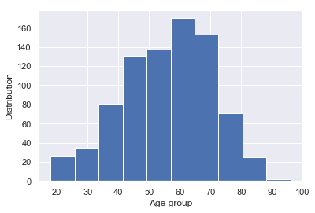

```python
sns.set()
_ = plt.hist(df_new['AGE'])
_ = plt.xlabel('Age group')
_ = plt.ylabel('Distribution')
plt.show()
```

Above is an observation of our age group distribution, the largest age group in our dataset is in the 60 to 70 age group.

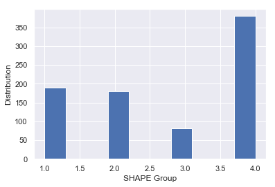

```python
sns.set()
_ = plt.hist(df_new['SHAPE'],)
_ = plt.xlabel('SHAPE Group')
_ = plt.ylabel('Distribution')
plt.show()
```

The 'SHAPE' is a variable ordered from round to irregular. SHAPE { 1: ROUND, 2: OVAL, 3: LOBULAR, 4: IRREGULAR }. As we can observe Irregular 'SHAPE' has the largest distribution on our dataset.

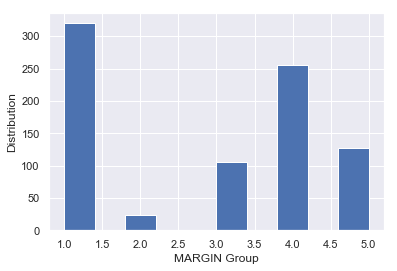

```python
sns.set()
_ = plt.hist(df_new['MARGIN'])
_ = plt.xlabel('MARGIN Group')
_ = plt.ylabel('Distribution')
plt.show()
```

The above distrubution visualize the attribute 'MARGIN':{1:circumscribed, 2:microlobulated, 3:obscured', 4:ill-defined, 5:spiculated}. From the distribution we also observe that the circumscribed values have the largest distrubutions.

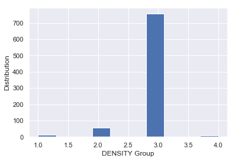

```python
sns.set()
_ = plt.hist(df_new['DENSITY'])
_ = plt.xlabel('DENSITY Group')
_ = plt.ylabel('Distribution')
plt.show()
```

The above plot describes the distribution of 'DENSITY' on our dataset. DENSITY: {1:high, 2:iso,3:low, 4: fat-containing}. From the distribution the largest category observed on our dataset is 3.0 which is the low Mass Density.

```
array([<matplotlib.axes._subplots.AxesSubplot object at 0x000002A32BC03EB8>,
      dtype=object)
```

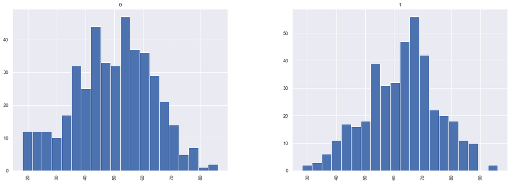

```python
df_new['AGE'].hist(by=df_new['SEVERITY'],bins=20, figsize=(20,7))
```

The Above figure is the distribution of our dataset AGE group with SEVERITY 1 and 0. We can observe that younger people are more likely to be zero or 'NO' values on SEVERITY than 1/'yes' value.

```
array([<matplotlib.axes._subplots.AxesSubplot object at 0x000002A32C0599B0>,
      dtype=object)
```

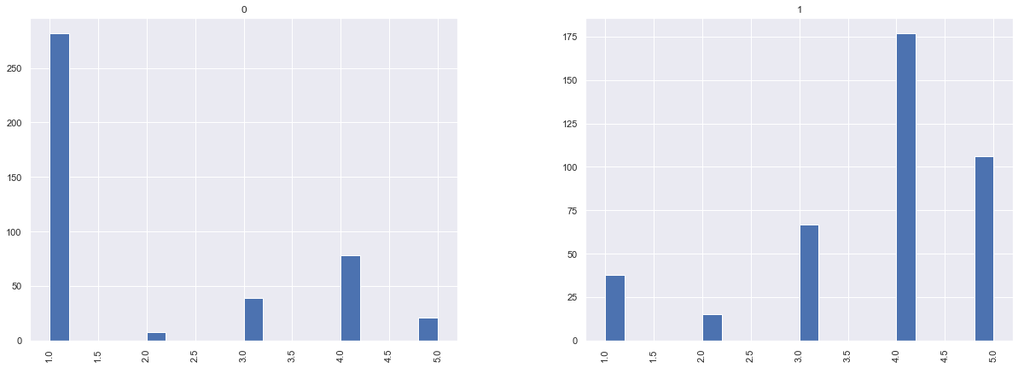

```python
df_new['MARGIN'].hist(by=df_new['SEVERITY'],bins=20, figsize=(20,7))
```

```
array([<matplotlib.axes._subplots.AxesSubplot object at 0x000002A32C170CF8>,
      dtype=object)
```

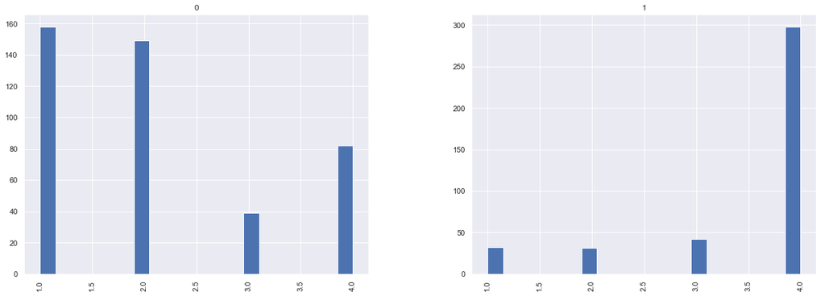

```python
df_new['SHAPE'].hist(by=df_new['SEVERITY'],bins=20, figsize=(20,7))
```

Now we have to standardize our dataset. StandardScaler standardizes a feature by subtracting the mean and then scaling to unit variance. Unit variance means dividing all the values by the standard deviation. StandardScaler results in a distribution with a standard deviation equal to 1.

```python
standardscaler = preprocessing.StandardScaler()
df_scaler= standardscaler.fit_transform(df_new)
```

```python
scaled_features_df = pd.DataFrame(df_scaler, index=df_new.index, columns=df_new.columns)
```

Now we have to split our dataset into train/test data set. Where 75% for training and 25% for Testing.

```python
y = scaled_features_df['SEVERITY']
attribute_columns=['AGE','SHAPE','MARGIN','DENSITY']
x = scaled_features_df[attribute_columns]
```

Above we 'y' defines the target variable and split our dataset in feature/attribute and target variable.

```python
#Creating a training and testing vars
x_train, x_test, y_train, y_test = train_test_split(x, y, test_size=0.25, random_state=1)
```

```python
#Check the shape of train
print(x_train.shape, y_train.shape)
```

```
(623, 4) (623,)
```

```python
#check the shape of test
print(x_test.shape, y_test.shape)
```

```
(208, 4) (208,)
```

Below is the creation of Decision Tree Model

```python
#we have to convert our target variable into an int since the classifier expects an int object and not a float
lab_enc = preprocessing.LabelEncoder()
y_train_encoded = lab_enc.fit_transform(y_train)
y_test_encoded = lab_enc.fit_transform(y_test)
#Decision Tree classifier
clf = DecisionTreeClassifier()
```

```python
#TRain Decision Tree
clf = clf.fit(x_train,y_train_encoded)
```

```python
#Predict response
y_pred = clf.predict(x_test)
```

```python
#Evaluate the model
print("Accuracy:", metrics.accuracy_score(y_test_encoded,y_pred))
```

```
Accuracy: 0.7067307692307693
```

Decision Tree Classifier has got 70.67% accuracy. Which is a good accuracy.

The following will utilize RandromForest Classifier for prediction

```python
clf = RandomForestClassifier(n_estimators=100)
```

```python
#Train model
clf.fit(x_train,y_train_encoded)
```

```
RandomForestClassifier(bootstrap=True, class_weight=None, criterion='gini',
            max_depth=None, max_features='auto', max_leaf_nodes=None,
            min_impurity_decrease=0.0, min_impurity_split=None,
            min_samples_leaf=1, min_samples_split=2,
            min_weight_fraction_leaf=0.0, n_estimators=100, n_jobs=None,
            oob_score=False, random_state=None, verbose=0,
            warm_start=False)
```

```python
#predict
y_pred = clf.predict(x_test)
```

```python
#Model accuracy
print("Accuracy:",metrics.accuracy_score(y_test_encoded,y_pred))
```

```
Accuracy: 0.7548076923076923
```

RandomForest classifier has produced 75.48% accuracy

The following will utilize the KNN classifier

```python
#KNN classifier created
knn = KNeighborsClassifier(n_neighbors=5)
```

```python
#Train Model
knn.fit(x_train,y_train_encoded)
```

```
KNeighborsClassifier(algorithm='auto', leaf_size=30, metric='minkowski',
           metric_params=None, n_jobs=None, n_neighbors=5, p=2,
           weights='uniform')
```

```python
#predict
y_pred=knn.predict(x_test)
```

```python
#Model accuracy
print("Accuracy:", metrics.accuracy_score(y_test_encoded,y_pred))
```

```
Accuracy: 0.7932692307692307
```

KNN has produced 79.32% accuracy.

The following will utilize Naive Bayes classifier.

```python
#Gaussian classifier created
gnb = GaussianNB()
```

```python
#Model Trained
gnb.fit(x_train,y_train_encoded)
```

```
GaussianNB(priors=None, var_smoothing=1e-09)
```

```python
#predict
y_pred=gnb.predict(x_test)
```

```python
#Model accuracy
print("Accuracy:",metrics.accuracy_score(y_test_encoded,y_pred))
```

```
Accuracy: 0.7980769230769231
```

Gaussian Classifier has produced 79.807 Accuracy ~ 80%

```python
#SVM classifier Created
clf = svm.SVC(kernel='linear')
```

```python
#Model Train
clf.fit(x_train,y_train_encoded)
```

```
SVC(C=1.0, cache_size=200, class_weight=None, coef0=0.0,
  decision_function_shape='ovr', degree=3, gamma='auto_deprecated',
  kernel='linear', max_iter=-1, probability=False, random_state=None,
  shrinking=True, tol=0.001, verbose=False)
```

```python
#predict
y_pred = clf.predict(x_test)
```

```python
#Model accuracy
print("Accuracy:",metrics.accuracy_score(y_test_encoded,y_pred))
```

```
Accuracy: 0.7884615384615384
```

The SVM classifier has produced 78.84% accuracy.